# IE360_HW3

Omer Erhan Erbis

1/9/2021

# Introduction

We are going to use some packages indicated below in our analysis. These are really important packagec for both data visualization, data manipulation and statistical operations.

```r
library(readxl)
library(zoo)
library(xts)
library(astsa)
library(ggplot2)
library(GGally)
library(fpp2)
library(gridExtra)
```

We will use Central Bank of the Republic of Turkey Electronic Data Delivery System (https://evds2.tcmb.gov.tr/) data in our analysis. It provides us with the minimum of monthly data of selected variables and monthly data will be used in here.

```r
EVDS <- read_excel("EVDS.xlsx",
                   col_types = c("text", "numeric",
                                 "numeric", "numeric", "numeric", "numeric", "numeric"))
```

## Variables

Variable of interest in this research will be the Consumer Price Index value for Alcoholic Beverages and Tobacco. This variable is important for many consumers, and also has a good market share in the total economy.

Also, in predicting Consumer Price Index value for Alcoholic Beverages and Tobacco, we will use several independent variables in our analysis to better estimate the value.

The chosen variables are USDTRY exchange rate, Interest Rates on TRY deposity, Consumer Confidence Index, Unemployment (%) and Labour Force (%). It is obvious that such core dynamics in an economy that are related to income and prices of mentioned goods are important in precise estimation.

## Data Manipulation & Time Series Conversion

```r
dataset <- EVDS


colnames(dataset) <- c("Date",
                       "USDTRY",
                       "Interest_Rates",
                       "CPI_Alcoholic_Beverages_and_Tobacco",
                       "CCI",
                       "Unemployment",
                       "Labour_Force")
dataset <- dataset[,c(1, 4, 2:3, 5:ncol(dataset))]
transform(dataset, Date = as.yearmon(Date))


dataset_xts <- as.xts(dataset[,-1], order.by = as.yearmon(dataset$Date))
```

```r
head(dataset_xts)
```

```
##          CPI_Alcoholic_Beverages_and_Tobacco   USDTRY Interest_Rates CCI
## Jul 2008                              192.60 1.209952        17.1675  NA
## Aug 2008                              192.62 1.172667        16.9540  NA
## Sep 2008                              192.64 1.229638        17.0775  NA
## Oct 2008                              192.66 1.473265        17.5360  NA
## Nov 2008                              192.61 1.587850        17.9700  NA
## Dec 2008                              192.61 1.538811        17.6300  NA
##          Unemployment Labour_Force
## Jul 2008          9.1         46.4
## Aug 2008          9.3         46.3
## Sep 2008          9.8         45.9
## Oct 2008         10.3         45.6
## Nov 2008         11.6         45.1
## Dec 2008         12.7         44.5
```

# Data Visualization

To better visualize the variables at hand, we will look both in given values and their log scale values of dependent variable and predictors.

Log scale helps us get rid of the variance of variances, sustaining some properties that are crucial in time series models for better fits.

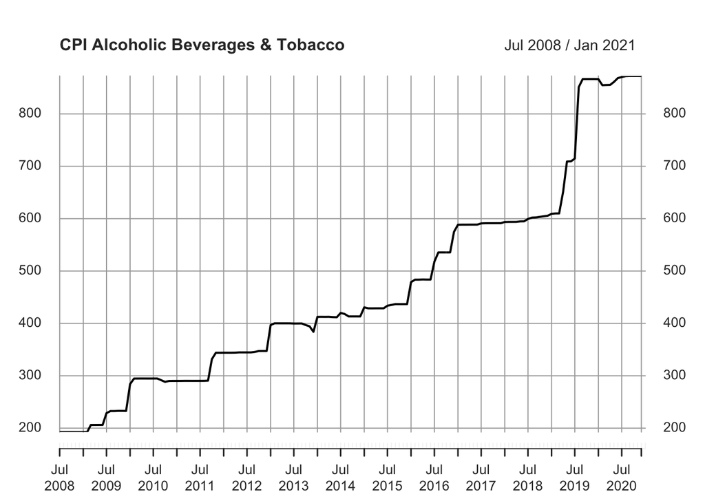

```r
plot(dataset_xts$CPI_Alcoholic_Beverages_and_Tobacco, main = "CPI Alcoholic Beverages & Tobacco")
```

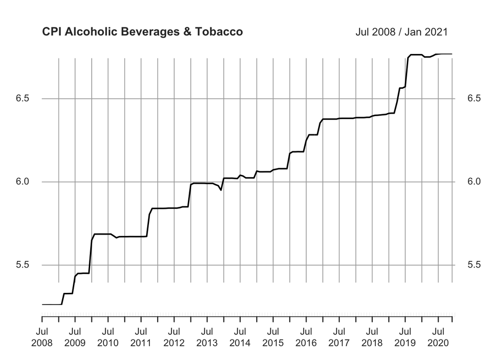

```r
plot(log(dataset_xts$CPI_Alcoholic_Beverages_and_Tobacco), main = "CPI Alcoholic Beverages & Tobacco")
```

As you can see, there is a clear upwards trend in the data, which will help us in constructing the model and predicting values.

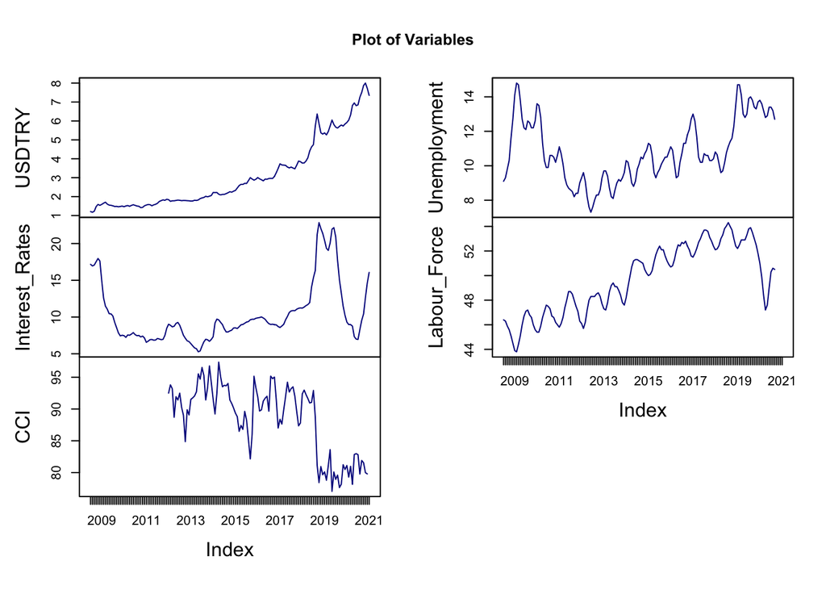

```r
plot.zoo(dataset_xts[,2:ncol(dataset_xts)], main = "Plot of Variables", col = "dark blue")
```

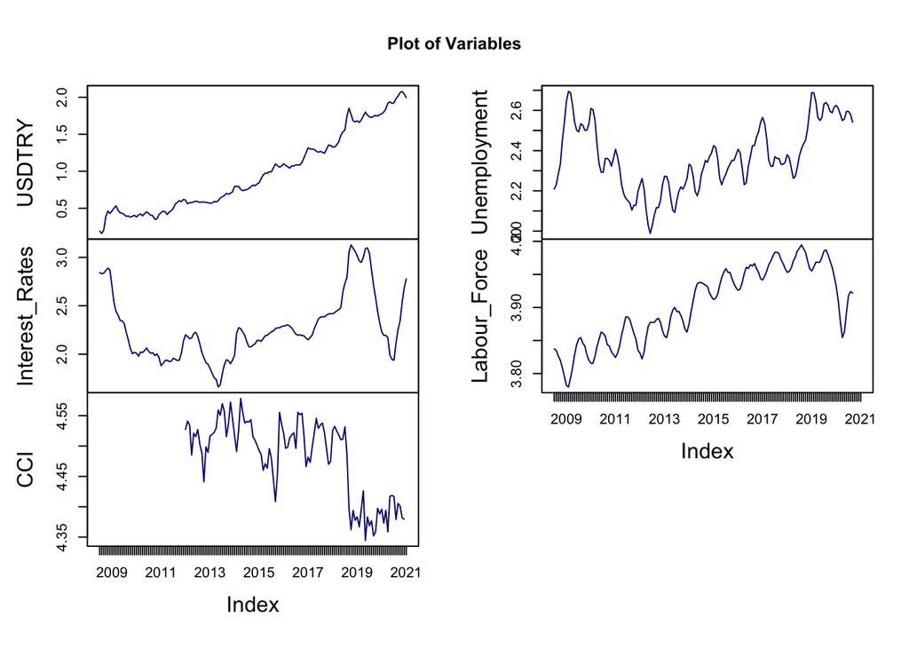

```r
plot.zoo(log(dataset_xts)[,2:ncol(dataset_xts)], main = "Plot of Variables", col = "dark blue")
```

There are a mixture of data in the plots above. There are some certain seasonalities that can easily observed and some trends that are easy to infer, but some remain indecisive at the first glance of the data visuals.

### Cross Correlations

Now, lets look at the correlations of datas with each other to better understand the situation and relationship between the data.

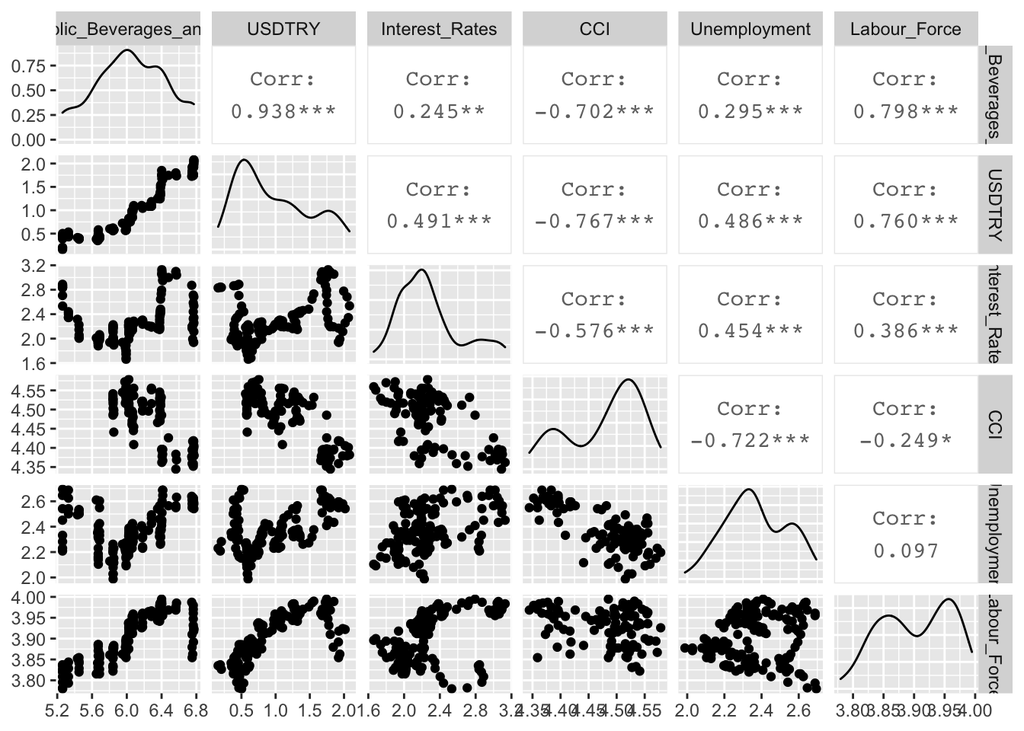

```r
ggpairs(as.data.frame(log(dataset_xts)))
```

All the variables chosen seems to have significant correlation values with variable of interest, making our chosen variables to be a good choice for the first look. We will benefit from these afterwards, in our regression analysis.

Now, lets run a basic regression model without regarding the time series property of the data.

```r
summary(lm(dataset_xts$CPI_Alcoholic_Beverages_and_Tobacco ~ ., dataset_xts))
```

```
##
## Call:
## lm(formula = dataset_xts$CPI_Alcoholic_Beverages_and_Tobacco ~
##     ., data = dataset_xts)
##
## Residuals:
##    Min     1Q Median     3Q    Max
## -99.79 -27.79   3.58  23.52 132.31
##
## Coefficients:
##                  Estimate Std. Error t value Pr(>|t|)
## (Intercept)    -327.38932  148.19927  -2.209 0.029472 *
## USDTRY           90.16220    5.03968  17.890  < 2e-16 ***
## Interest_Rates  -12.25138    1.45094  -8.444 2.66e-13 ***
## CCI              -0.07628    1.36076  -0.056 0.955411
## Unemployment     16.17929    4.21444   3.839 0.000218 ***
## Labour_Force      9.93420    2.58158   3.848 0.000211 ***
## ---
## Signif. codes:  0 '***' 0.001 '**' 0.01 '*' 0.05 '.' 0.1 ' ' 1
##
## Residual standard error: 39.95 on 99 degrees of freedom
##   (46 observations deleted due to missingness)
## Multiple R-squared:  0.9415, Adjusted R-squared:  0.9386
## F-statistic: 318.8 on 5 and 99 DF,  p-value: < 2.2e-16
```

It seems that except CCI, all other variables will have a great impact on the calculation of the variable of interest.

### Decomposed for Time Series Qualities

Yet again, lets do a basic trend, seasonality and error extraction from the variable of interest with the decompose() function. It runs a simple regression with the 2 variables mentioned and returns individual properties of these.

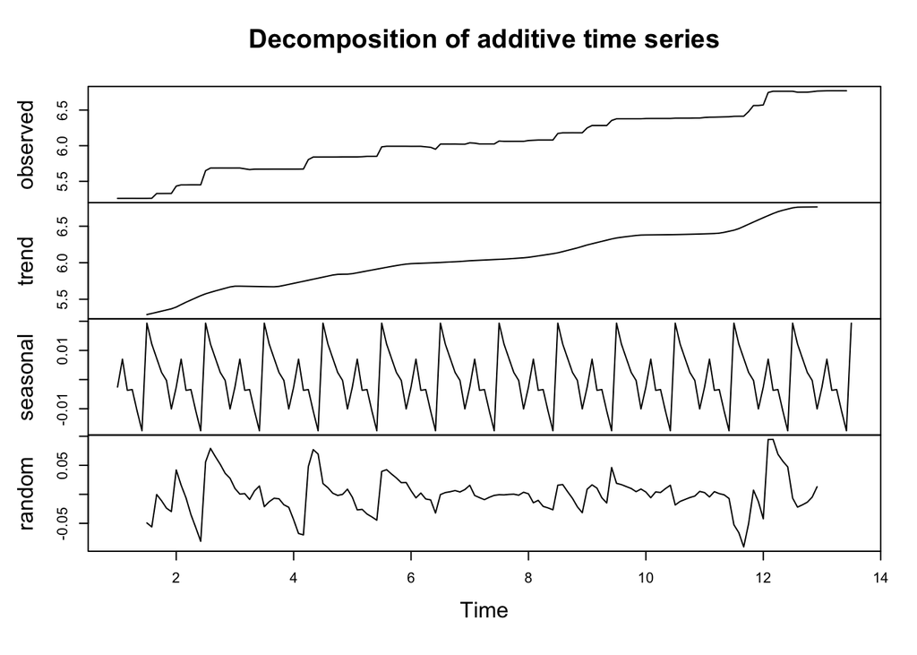

```r
plot(decompose(as.ts(log(dataset_xts$CPI_Alcoholic_Beverages_and_Tobacco))))
```

As we can see, the trend and seasonality in the variale of interest is clearly shown. Also, the error values remains at a neat level for time series analysis requirements.

## Auto-Correlation Tables

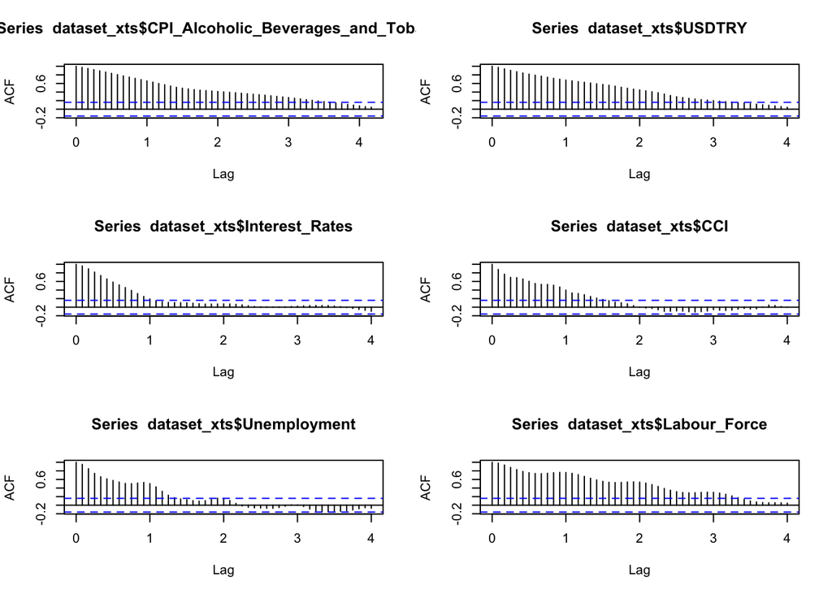

```r
par(mfrow = c(3,2))
acf(dataset_xts$CPI_Alcoholic_Beverages_and_Tobacco, lag.max = 50, na.action = na.pass)
acf(dataset_xts$USDTRY, lag.max = 48, na.action = na.pass)
acf(dataset_xts$Interest_Rates, lag.max = 48, na.action = na.pass)
acf(dataset_xts$CCI, lag.max = 48, na.action = na.pass)
acf(dataset_xts$Unemployment, lag.max = 48, na.action = na.pass)
acf(dataset_xts$Labour_Force, lag.max = 48, na.action = na.pass)
```

```r
par(mfrow = c(1,1))
```

As can be seen above, time series properties of the variables are clearly observable. It is important to notice the auto-correlation values of these variables for understanding the state of data.

We cannot clearly see the importance of any lag for the variable of interest, therefore we will run a partial auto-correlation analysis to infer lag values that will help us in the construction of the model.

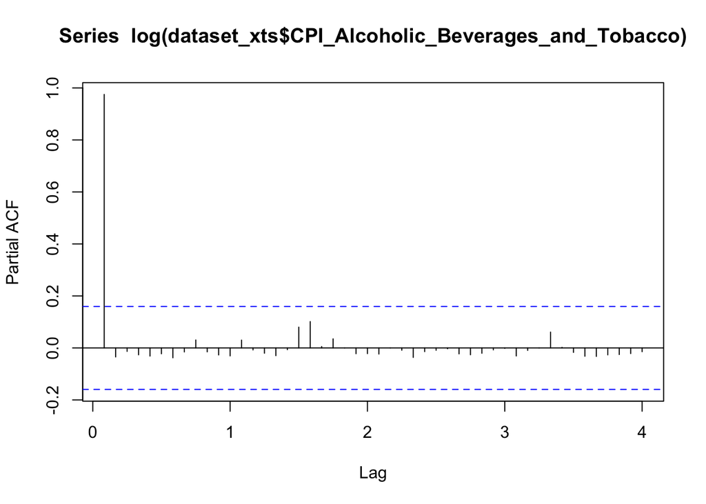

```r
pacf(log(dataset_xts$CPI_Alcoholic_Beverages_and_Tobacco), lag.max = 48, na.action = na.pass)
```

It seems that only the lag_1 value will be meaningful for our regression analysis, and other lag values will be represented mostly by this lag only. Therefore, it is enough to use lag_1 in analysis.

For interest, it is also plausible to look at cross-correlations between variable of interest and regressor variables. This will further strengthen the analysis results, but will be disregarded as out of scope in this homework.

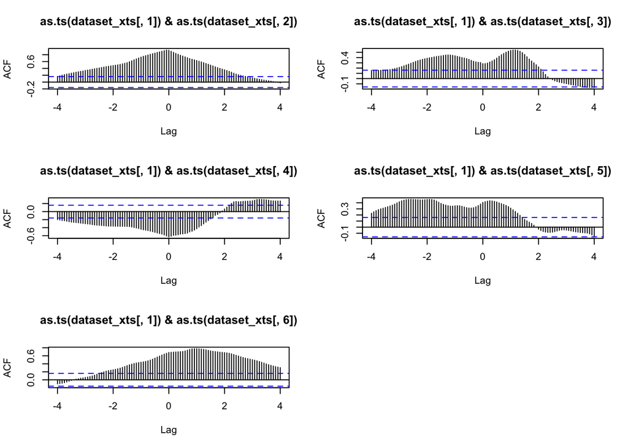

```r
par(mfrow = c(3,2))
ccf(as.ts(dataset_xts[,1]), as.ts(dataset_xts[,2]), na.action = na.pass, lag.max = 48)
ccf(as.ts(dataset_xts[,1]), as.ts(dataset_xts[,3]), na.action = na.pass, lag.max = 48)
ccf(as.ts(dataset_xts[,1]), as.ts(dataset_xts[,4]), na.action = na.pass, lag.max = 48)
ccf(as.ts(dataset_xts[,1]), as.ts(dataset_xts[,5]), na.action = na.pass, lag.max = 48)
ccf(as.ts(dataset_xts[,1]), as.ts(dataset_xts[,6]), na.action = na.pass, lag.max = 48)
par(mfrow = c(1,1))
```

## Time Series Variables

First of all, lets introduce the lag_1 values into our data.

```r
# lag_1
dataset_xts$lag_1 <- c(NA, as.data.frame(dataset_xts)[-nrow(dataset_xts),1])
```

And now, we can track the trend by adding a column containing a series indicating the point of time. This will track down the increasing or decreasing trend if present and return the value in the analysis.

```r
# trend
dataset_xts$trend <- 1:nrow(dataset_xts)
```

Lastly, as we observed previously, there is a yearly seasonality in our data. To track this down and include this important feature in our regression analysis, we will introduce dummy variables that corresponds to months of a year to include in our regression analysis.

```r
# season

dataset_xts$january     <- rep(c(0,0,0,0,0,0,1,0,0,0,0,0), length.out = 151)
dataset_xts$february    <- rep(c(0,0,0,0,0,0,0,1,0,0,0,0), length.out = 151)
dataset_xts$march       <- rep(c(0,0,0,0,0,0,0,0,1,0,0,0), length.out = 151)
dataset_xts$april       <- rep(c(0,0,0,0,0,0,0,0,0,1,0,0), length.out = 151)
dataset_xts$may         <- rep(c(0,0,0,0,0,0,0,0,0,0,1,0), length.out = 151)
dataset_xts$june        <- rep(c(0,0,0,0,0,0,0,0,0,0,0,1), length.out = 151)
dataset_xts$july        <- rep(c(1,0,0,0,0,0,0,0,0,0,0,0), length.out = 151)
dataset_xts$august      <- rep(c(0,1,0,0,0,0,0,0,0,0,0,0), length.out = 151)
dataset_xts$september   <- rep(c(0,0,1,0,0,0,0,0,0,0,0,0), length.out = 151)
dataset_xts$october     <- rep(c(0,0,0,1,0,0,0,0,0,0,0,0), length.out = 151)
dataset_xts$november    <- rep(c(0,0,0,0,1,0,0,0,0,0,0,0), length.out = 151)
dataset_xts$december    <- rep(c(0,0,0,0,0,1,0,0,0,0,0,0), length.out = 151)
```

To see the final sample of our data, see below:

```r
head(dataset_xts)
```

```
##          CPI_Alcoholic_Beverages_and_Tobacco   USDTRY Interest_Rates CCI
## Jul 2008                              192.60 1.209952        17.1675  NA
## Aug 2008                              192.62 1.172667        16.9540  NA
## Sep 2008                              192.64 1.229638        17.0775  NA
## Oct 2008                              192.66 1.473265        17.5360  NA
## Nov 2008                              192.61 1.587850        17.9700  NA
## Dec 2008                              192.61 1.538811        17.6300  NA
##          Unemployment Labour_Force  lag_1 trend january february march april
## Jul 2008          9.1         46.4     NA     1       0        0     0     0
## Aug 2008          9.3         46.3 192.60     2       0        0     0     0
## Sep 2008          9.8         45.9 192.62     3       0        0     0     0
## Oct 2008         10.3         45.6 192.64     4       0        0     0     0
## Nov 2008         11.6         45.1 192.66     5       0        0     0     0
## Dec 2008         12.7         44.5 192.61     6       0        0     0     0
##          may june july august september october november december
## Jul 2008   0    0    1      0         0       0        0        0
## Aug 2008   0    0    0      1         0       0        0        0
## Sep 2008   0    0    0      0         1       0        0        0
## Oct 2008   0    0    0      0         0       1        0        0
## Nov 2008   0    0    0      0         0       0        1        0
## Dec 2008   0    0    0      0         0       0        0        1
```

## Regression

To run our data, we will introduce the training set until November 2020. And we will run our linear regression model to estimate the coefficients of related regressors.

```r
dataset1 <- dataset_xts[-c(nrow(dataset_xts)-1, nrow(dataset_xts)),]


fit <- (lm(data = dataset1, formula = CPI_Alcoholic_Beverages_and_Tobacco ~ . -december))
summary(fit)
```

```
##
## Call:
## lm(formula = CPI_Alcoholic_Beverages_and_Tobacco ~ . - december,
##     data = dataset1)
##
## Residuals:
##     Min      1Q  Median      3Q     Max
## -32.037  -5.744  -1.432   3.217 103.597
##
## Coefficients:
##                  Estimate Std. Error t value Pr(>|t|)
## (Intercept)     58.432645 124.666254   0.469   0.6405
## USDTRY          -5.372250   6.990049  -0.769   0.4443
## Interest_Rates   0.558270   0.875399   0.638   0.5253
## CCI             -0.573886   0.594215  -0.966   0.3369
## Unemployment     5.627358   2.388025   2.356   0.0207 *
## Labour_Force    -1.068626   2.383760  -0.448   0.6551
## lag_1            0.959810   0.046118  20.812   <2e-16 ***
## trend            0.202318   0.438659   0.461   0.6458
## january         12.459580   7.899344   1.577   0.1184
## february        -4.898439   7.847549  -0.624   0.5341
## march           -0.350041   7.847160  -0.045   0.9645
## april            9.873389   8.313232   1.188   0.2382
## may             14.540811   8.705966   1.670   0.0985 .
## june             7.365442   8.705006   0.846   0.3998
## july            10.938329   8.621794   1.269   0.2080
## august          21.023392   8.834075   2.380   0.0195 *
## september        4.355216   8.822860   0.494   0.6228
## october          0.729445   8.501018   0.086   0.9318
## november         0.004763   8.154203   0.001   0.9995
## ---
## Signif. codes:  0 '***' 0.001 '**' 0.01 '*' 0.05 '.' 0.1 ' ' 1
##
## Residual standard error: 16 on 86 degrees of freedom
##   (44 observations deleted due to missingness)
## Multiple R-squared:  0.9919, Adjusted R-squared:  0.9901
## F-statistic: 581.7 on 18 and 86 DF,  p-value: < 2.2e-16
```

It is surprising that none of the variables of interest are significantly affecting the variable of interest, and it is only affected by its lag_1 value very significantly. This asserts that variable of interest is independent of the other variables chosen. This may result from inefficient variable choosing or simply independence of the variable and strong dependence of its own to its previous lags. On top of that, unemployment value also seems somewhat important in the prediction of variable. Conclusions can be made from this analysis.

Lastly, fitting the model and using the December 2020 data, and last available values of unemployment and labour force as vague proxies, we will obtain a predicted value for that time period.

```r
pseudo <- dataset_xts[147, c(5,6)]
index(pseudo) <- index(dataset_xts[150,])


newdataforpredict <- cbind(dataset_xts[150, c(1:4, 7:ncol(dataset_xts))], pseudo)
predict(fit, newdata = newdataforpredict)
```

```
## Dec 2020
## 864.5483
```

# Results & Possible Explanations

All in all, the time series regression resulted in a somewhat failure due to high correlation with previous periods and increasing trend. Predictions using only previous period data seems to be more efficient for computer power regard. R-squared value however is very powerful, indicating a success in the estimation capabilities of the model. This result may come from increasing tax applications and increasing demand on the goods referred that are not captured in the variables chosen.

## Alternative Models

```r
fit <- (lm(data = dataset1, formula = log(CPI_Alcoholic_Beverages_and_Tobacco) ~ log(USDTRY) +
             log(Interest_Rates) +
             log(CCI) +
             log(Unemployment) +
             log(Labour_Force)))

summary(fit)
```

```
##
## Call:
## lm(formula = log(CPI_Alcoholic_Beverages_and_Tobacco) ~ log(USDTRY) +
##     log(Interest_Rates) + log(CCI) + log(Unemployment) + log(Labour_Force),
##     data = dataset1)
##
## Residuals:
##       Min        1Q    Median        3Q       Max
## -0.144199 -0.043481  0.008992  0.044132  0.200020
##
## Coefficients:
##                     Estimate Std. Error t value Pr(>|t|)
## (Intercept)          2.91605    0.93169   3.130  0.00230 **
## log(USDTRY)          0.63374    0.03343  18.957  < 2e-16 ***
## log(Interest_Rates) -0.22383    0.03110  -7.197 1.21e-10 ***
## log(CCI)             0.12654    0.18349   0.690  0.49205
## log(Unemployment)    0.21456    0.07602   2.822  0.00576 **
## log(Labour_Force)    0.51642    0.24034   2.149  0.03410 *
## ---
## Signif. codes:  0 '***' 0.001 '**' 0.01 '*' 0.05 '.' 0.1 ' ' 1
##
## Residual standard error: 0.06486 on 99 degrees of freedom
##   (44 observations deleted due to missingness)
## Multiple R-squared:  0.9504, Adjusted R-squared:  0.9479
## F-statistic: 379.4 on 5 and 99 DF,  p-value: < 2.2e-16
```

```r
fit <- (lm(data = dataset1, formula = log(CPI_Alcoholic_Beverages_and_Tobacco) ~ log(USDTRY) +
             log(Interest_Rates) +
             log(CCI) +
             log(Unemployment) +
             log(Labour_Force) +
             trend))

summary(fit)
```

```
##
## Call:
## lm(formula = log(CPI_Alcoholic_Beverages_and_Tobacco) ~ log(USDTRY) +
##     log(Interest_Rates) + log(CCI) + log(Unemployment) + log(Labour_Force) +
##     trend, data = dataset1)
##
## Residuals:
##       Min        1Q    Median        3Q       Max
## -0.103101 -0.037823 -0.006649  0.038408  0.189884
##
## Coefficients:
##                      Estimate Std. Error t value Pr(>|t|)
## (Intercept)          8.236628   1.218425   6.760 1.00e-09 ***
## log(USDTRY)          0.035068   0.106722   0.329 0.743166
## log(Interest_Rates) -0.121814   0.032127  -3.792 0.000259 ***
## log(CCI)            -0.172042   0.166977  -1.030 0.305390
## log(Unemployment)    0.046688   0.071867   0.650 0.517440
## log(Labour_Force)   -0.505538   0.272173  -1.857 0.066255 .
## trend                0.009367   0.001607   5.828 7.16e-08 ***
## ---
## Signif. codes:  0 '***' 0.001 '**' 0.01 '*' 0.05 '.' 0.1 ' ' 1
##
## Residual standard error: 0.05618 on 98 degrees of freedom
##   (44 observations deleted due to missingness)
## Multiple R-squared:  0.9632, Adjusted R-squared:  0.9609
## F-statistic: 427.1 on 6 and 98 DF,  p-value: < 2.2e-16
```

```r
fit <- (lm(data = dataset1, formula = log(CPI_Alcoholic_Beverages_and_Tobacco) ~ log(USDTRY) +
             log(Interest_Rates) +
             log(CCI) +
             log(Unemployment) +
             log(Labour_Force) +
             log(lag_1) +
             trend))
summary(fit)
```

```
##
## Call:
## lm(formula = log(CPI_Alcoholic_Beverages_and_Tobacco) ~ log(USDTRY) +
##     log(Interest_Rates) + log(CCI) + log(Unemployment) + log(Labour_Force) +
##     log(lag_1) + trend, data = dataset1)
##
## Residuals:
##       Min        1Q    Median        3Q       Max
## -0.036131 -0.012478 -0.003252  0.002976  0.153108
##
## Coefficients:
##                       Estimate Std. Error t value Pr(>|t|)
## (Intercept)          0.4849935  0.7245371   0.669   0.5048
## log(USDTRY)         -0.0012049  0.0512615  -0.024   0.9813
## log(Interest_Rates) -0.0049709  0.0167134  -0.297   0.7668
## log(CCI)            -0.0431529  0.0804578  -0.536   0.5929
## log(Unemployment)    0.0833538  0.0345530   2.412   0.0177 *
## log(Labour_Force)    0.0153482  0.1337579   0.115   0.9089
## log(lag_1)           0.9078576  0.0500965  18.122   <2e-16 ***
## trend                0.0004955  0.0009136   0.542   0.5888
## ---
## Signif. codes:  0 '***' 0.001 '**' 0.01 '*' 0.05 '.' 0.1 ' ' 1
##
## Residual standard error: 0.02696 on 97 degrees of freedom
##   (44 observations deleted due to missingness)
## Multiple R-squared:  0.9916, Adjusted R-squared:  0.991
## F-statistic:  1636 on 7 and 97 DF,  p-value: < 2.2e-16
```

```r
# lag_12
dataset1$lag_12 <- c(rep(NA, 12), as.data.frame(dataset1)[-c((nrow(dataset1)-11):nrow(dataset1)),1])


fit <- (lm(data = dataset1, formula = log(CPI_Alcoholic_Beverages_and_Tobacco) ~ log(USDTRY) +
             log(Interest_Rates) +
             log(CCI) +
             log(Unemployment) +
             log(Labour_Force) +
             log(lag_12) +
             trend))
summary(fit)
```

```
##
## Call:
## lm(formula = log(CPI_Alcoholic_Beverages_and_Tobacco) ~ log(USDTRY) +
##     log(Interest_Rates) + log(CCI) + log(Unemployment) + log(Labour_Force) +
##     log(lag_12) + trend, data = dataset1)
##
## Residuals:
##       Min        1Q    Median        3Q       Max
## -0.113216 -0.034585 -0.003056  0.038131  0.186730
##
## Coefficients:
##                      Estimate Std. Error t value Pr(>|t|)
## (Intercept)          9.209878   1.313364   7.012 3.15e-10 ***
## log(USDTRY)          0.048145   0.105660   0.456 0.649651
## log(Interest_Rates) -0.124663   0.031773  -3.924 0.000163 ***
## log(CCI)            -0.140901   0.165801  -0.850 0.397518
## log(Unemployment)    0.024704   0.071979   0.343 0.732179
## log(Labour_Force)   -0.530841   0.269209  -1.972 0.051475 .
## log(lag_12)         -0.182009   0.098295  -1.852 0.067117 .
## trend                0.010881   0.001786   6.093 2.24e-08 ***
## ---
## Signif. codes:  0 '***' 0.001 '**' 0.01 '*' 0.05 '.' 0.1 ' ' 1
##
## Residual standard error: 0.0555 on 97 degrees of freedom
##   (44 observations deleted due to missingness)
## Multiple R-squared:  0.9644, Adjusted R-squared:  0.9619
## F-statistic: 375.6 on 7 and 97 DF,  p-value: < 2.2e-16
```

### References

Central Bank of the Republic of Turkey Electronic Data Delivery System (https://evds2.tcmb.gov.tr/)

https://stackoverflow.com